# Scientific Python

#### Author : Juhyung Kang (Seoul National University)

#### Email : jhkang@astro.snu.ac.kr

In this section, we learn some basic scientific functions and packages. We use the [NumPy](http://www.numpy.org/), [SciPy](https://www.scipy.org/), [Matplotlib](https://matplotlib.org/), [Interpolation](https://github.com/econforge/interpolation.py), [AstroPy](http://www.astropy.org/) and [SunPy](http://sunpy.org/) packages.

**Required packages**

> - [Python](http://www.python.org) v2.7 or 3.5 or 3.6
> - [NumPy](http://www.numpy.org/) v1.7+
> - [SciPy](https://www.scipy.org/) v1.0+
> - [Matplotlib](https://matplotlib.org/) v2.0+
> - [AstroPy](http://www.astropy.org/) v2.0+

[figure not shown]

> - [SunPy](http://sunpy.org/) v0.8+ (Warning ! : This package is developing package, so that some of functions can be depricated)

[figure not shown]

> - [Interpolation](https://github.com/econforge/interpolation.py) v0.18+

Above requried packages can be downloaded by using conda command in your cmd prompt or terminal as below :

```
conda install -c condaforge sunpy astropy interpolation
```

This tutorial is based on the [Scipy-Lecture notes](http://www.scipy-lectures.org).

**You can download this tutorial file on the [Scientific-python](http://fiss.snu.ac.kr/tutorial/scientific_python) FISS website below**

### http://fiss.snu.ac.kr/tutorial/scientific_python

and some examples files.

# 1. Compatibility

Some of calling syntaxes are differen according to python version. The main differences are print statement and division operator. In python 2, division operator '**/**' is the floor division, but in python3 it isn't the floor division. In python3 floor division syntax is '**//**' To avoid this compatibility problem, we import the "**future**" method.

```python
from __future__ import division, print_function
```

# 2. Array (NumPy package)

To call arrays in python, we have to import the **numpy** package at first.

```python
import numpy as np
```

## 2.1. Manual construction of arrays

```python
a = np.array([1,5,2,4,3,0])
a
```

```
array([1, 5, 2, 4, 3, 0])
```

This array can be sort by using **sort** function

```python
a.sort()
a
```

```
array([0, 1, 2, 3, 4, 5])
```

```python
a.dtype
```

```
dtype('int32')
```

```python
b = np.array([[0,1,2],[3,4,5]],dtype = 'float')
b
```

```
array([[ 0.,  1.,  2.],
       [ 3.,  4.,  5.]])
```

```python
b.dtype
```

```
dtype('float64')
```

```python
b.shape          # Same with the size function in IDL
```

```
(2, 3)
```

```python
len(b)           # returns the size of the first dimension
```

```
2
```

convert row array to column array

```python
c = a[:,None]
c
```

```
array([[0],
       [1],
       [2],
       [3],
       [4],
       [5]])
```

## 2.2 Functions for creating arrays

```python
a = np.arange(6)   # similar with the *indgen functions in IDL
a
```

```
array([0, 1, 2, 3, 4, 5])
```

```python
b = np.arange(0,10,0.1)
b
```

```
array([ 0. ,  0.1,  0.2,  0.3,  0.4,  0.5,  0.6,  0.7,  0.8,  0.9,  1. ,
        1.1,  1.2,  1.3,  1.4,  1.5,  1.6,  1.7,  1.8,  1.9,  2. ,  2.1,
        2.2,  2.3,  2.4,  2.5,  2.6,  2.7,  2.8,  2.9,  3. ,  3.1,  3.2,
        3.3,  3.4,  3.5,  3.6,  3.7,  3.8,  3.9,  4. ,  4.1,  4.2,  4.3,
        4.4,  4.5,  4.6,  4.7,  4.8,  4.9,  5. ,  5.1,  5.2,  5.3,  5.4,
        5.5,  5.6,  5.7,  5.8,  5.9,  6. ,  6.1,  6.2,  6.3,  6.4,  6.5,
        6.6,  6.7,  6.8,  6.9,  7. ,  7.1,  7.2,  7.3,  7.4,  7.5,  7.6,
        7.7,  7.8,  7.9,  8. ,  8.1,  8.2,  8.3,  8.4,  8.5,  8.6,  8.7,
        8.8,  8.9,  9. ,  9.1,  9.2,  9.3,  9.4,  9.5,  9.6,  9.7,  9.8,
        9.9])
```

```python
np.arange?
```

```python
c = np.linspace(0,10,101)
c
```

```
array([  0. ,   0.1,   0.2,   0.3,   0.4,   0.5,   0.6,   0.7,   0.8,
         0.9,   1. ,   1.1,   1.2,   1.3,   1.4,   1.5,   1.6,   1.7,
         1.8,   1.9,   2. ,   2.1,   2.2,   2.3,   2.4,   2.5,   2.6,
         2.7,   2.8,   2.9,   3. ,   3.1,   3.2,   3.3,   3.4,   3.5,
         3.6,   3.7,   3.8,   3.9,   4. ,   4.1,   4.2,   4.3,   4.4,
         4.5,   4.6,   4.7,   4.8,   4.9,   5. ,   5.1,   5.2,   5.3,
         5.4,   5.5,   5.6,   5.7,   5.8,   5.9,   6. ,   6.1,   6.2,
         6.3,   6.4,   6.5,   6.6,   6.7,   6.8,   6.9,   7. ,   7.1,
         7.2,   7.3,   7.4,   7.5,   7.6,   7.7,   7.8,   7.9,   8. ,
         8.1,   8.2,   8.3,   8.4,   8.5,   8.6,   8.7,   8.8,   8.9,
         9. ,   9.1,   9.2,   9.3,   9.4,   9.5,   9.6,   9.7,   9.8,
         9.9,  10. ])
```

```python
np.linspace?
```

```python
one = np.ones((3,3))
```

```python
one
```

```
array([[ 1.,  1.,  1.],
       [ 1.,  1.,  1.],
       [ 1.,  1.,  1.]])
```

```python
zero = np.zeros((2,3))
```

```python
zero
```

```
array([[ 0.,  0.,  0.],
       [ 0.,  0.,  0.]])
```

```python
np.random.seed(2018)
```

```python
randu = np.random.rand(4)   #uniform random number generator
randu
```

```
array([ 0.88234931,  0.10432774,  0.90700933,  0.3063989 ])
```

```python
randg = np.random.randn(5) #gaussian random number generator
randg
```

```
array([ 2.14839926, -1.279487  ,  0.50227689,  0.8560293 , -0.14279008])
```

#### Exercise 1) Create an array which has equaily spaced elements from 5 to 100 with step size = 5 .

#### Exercise 2) Create an array which has 100 equaily spaced elements from 0 to 2

## 2.3. Indexing and slicing

```python
a = np.arange(10)
```

```python
a[0]
```

```
0
```

```python
a[:]
```

```
array([0, 1, 2, 3, 4, 5, 6, 7, 8, 9])
```

```python
a[3:6]
```

```
array([3, 4, 5])
```

```python
a[3:8:2]
```

```
array([3, 5, 7])
```

```python
a[3:]
```

```
array([3, 4, 5, 6, 7, 8, 9])
```

#### Array reshaping

```python
d=np.arange(25)
```

```python
d = d.reshape((5,5))
```

```python
d
```

```
array([[ 0,  1,  2,  3,  4],
       [ 5,  6,  7,  8,  9],
       [10, 11, 12, 13, 14],
       [15, 16, 17, 18, 19],
       [20, 21, 22, 23, 24]])
```

```python
d[3]
```

```
array([15, 16, 17, 18, 19])
```

```python
d[:,3]
```

```
array([ 3,  8, 13, 18, 23])
```

```python
b = d.transpose()
```

```python
b[3]
```

```
array([ 3,  8, 13, 18, 23])
```

```python
d[:2]
```

```
array([[0, 1, 2, 3, 4],
       [5, 6, 7, 8, 9]])
```

## 2.4. Broadcasting

```python
a = np.arange(5)
```

```python
b = np.ones(5, dtype=int)
```

```python
a
```

```
array([0, 1, 2, 3, 4])
```

```python
b
```

```
array([1, 1, 1, 1, 1])
```

```python
c = a+b[:,None]
```

```python
c
```

```
array([[1, 2, 3, 4, 5],
       [1, 2, 3, 4, 5],
       [1, 2, 3, 4, 5],
       [1, 2, 3, 4, 5],
       [1, 2, 3, 4, 5]])
```

```python
c + a
```

```
array([[1, 3, 5, 7, 9],
       [1, 3, 5, 7, 9],
       [1, 3, 5, 7, 9],
       [1, 3, 5, 7, 9],
       [1, 3, 5, 7, 9]])
```

```python
c + a[:,None]
```

```
array([[1, 2, 3, 4, 5],
       [2, 3, 4, 5, 6],
       [3, 4, 5, 6, 7],
       [4, 5, 6, 7, 8],
       [5, 6, 7, 8, 9]])
```

**Exercise 3) Create the $10 \times 10$ multiplication table. (Do not use 'for' loop.)**

[figure not shown]

## 2.5. Boolean operation

```python
c
```

```
array([[1, 2, 3, 4, 5],
       [1, 2, 3, 4, 5],
       [1, 2, 3, 4, 5],
       [1, 2, 3, 4, 5],
       [1, 2, 3, 4, 5]])
```

```python
c == 1
```

```
array([[ True, False, False, False, False],
       [ True, False, False, False, False],
       [ True, False, False, False, False],
       [ True, False, False, False, False],
       [ True, False, False, False, False]], dtype=bool)
```

```python
b
```

```
array([1, 1, 1, 1, 1])
```

```python
mask = c <= b
```

```python
mask
```

```
array([[ True, False, False, False, False],
       [ True, False, False, False, False],
       [ True, False, False, False, False],
       [ True, False, False, False, False],
       [ True, False, False, False, False]], dtype=bool)
```

```python
d
```

```
array([[ 0,  1,  2,  3,  4],
       [ 5,  6,  7,  8,  9],
       [10, 11, 12, 13, 14],
       [15, 16, 17, 18, 19],
       [20, 21, 22, 23, 24]])
```

```python
d[mask]
```

```
array([ 0,  5, 10, 15, 20])
```

```python
np.where(mask)
```

```
(array([0, 1, 2, 3, 4], dtype=int64), array([0, 0, 0, 0, 0], dtype=int64))
```

```python
True or False
```

```
True
```

```python
True and False
```

```
False
```

```python
mask1 = np.array([True,False,False,True,False])
mask2 = np.array([True,True,False,True,False])
```

```python
mask1 or mask
```

```
---------------------------------------------------------------------------
ValueError                                Traceback (most recent call last)
<ipython-input-56-df0b0dad315b> in <module>()
----> 1 mask1 or mask

ValueError: The truth value of an array with more than one element is ambiguous. Use a.any() or a.all()
```

```python
mask1 and mask2
```

```
---------------------------------------------------------------------------
ValueError                                Traceback (most recent call last)
<ipython-input-57-d93ac612a2e9> in <module>()
----> 1 mask1 and mask2

ValueError: The truth value of an array with more than one element is ambiguous. Use a.any() or a.all()
```

```python
np.logical_and(mask1, mask2)
```

```
array([ True, False, False,  True, False], dtype=bool)
```

```python
np.logical_or(mask1, mask2)
```

```
array([ True,  True, False,  True, False], dtype=bool)
```

## 2.6. Basic reduction

[figure not shown]

```python
d[0,3]=-1
d[2,2]=-10
```

```python
d
```

```
array([[  0,   1,   2,  -1,   4],
       [  5,   6,   7,   8,   9],
       [ 10,  11, -10,  13,  14],
       [ 15,  16,  17,  18,  19],
       [ 20,  21,  22,  23,  24]])
```

```python
d.sum()
```

```
274
```

```python
d.sum(0)
```

```
array([50, 55, 38, 61, 70])
```

```python
d.mean(1)
```

```
array([  1.2,   7. ,   7.6,  17. ,  22. ])
```

```python
d.min(1)
```

```
array([ -1,   5, -10,  15,  20])
```

```python
d.argmin(1)
```

```
array([3, 0, 2, 0, 0], dtype=int64)
```

**Exercise 4) Create the 10x10 gaussian random number, and find the minimum value along the axis 0**

# 3. Plotting (Matplotlib package)

In this section, we are going to learn a simple way to visualize data in interactive mode by using the matplotlib package. matplotlib package is based on the Matlab plot device.

First we change the default backend mode to interactive mode in the IPython console.

```python
%matplotlib
```

```
Using matplotlib backend: Qt5Agg
```

If you use the Jupyter notebook like this manual, type the magic funcition like below:

```python
%matplotlib notebook
```

or :

```python
%matplotlib inline
```

## 3.1. Simple plot

Then import the pyplot module in matplotlib package.

```python
import matplotlib.pyplot as plt
```

```python
theta = np.linspace(-np.pi, np.pi,151)
c = np.cos(theta)
s = np.sin(theta)
```

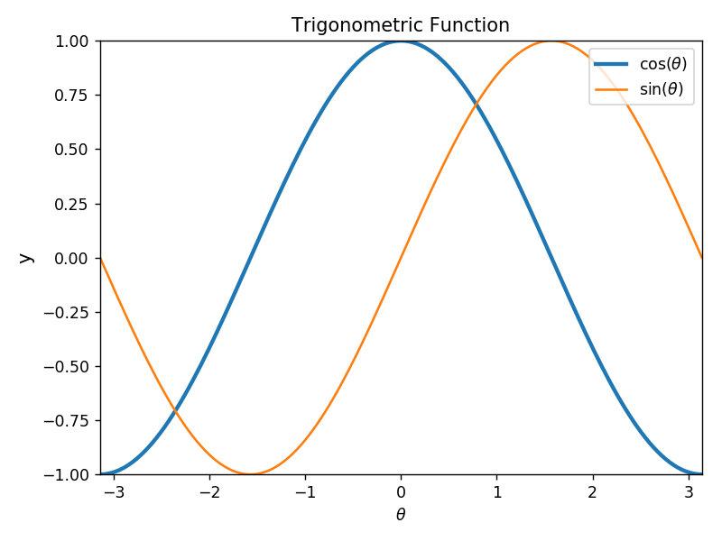

```python
plt.plot(theta, c, lw = 2.5, label= r'cos($\theta$)')
plt.plot(theta, s, label= r'sin($\theta$)')
```

```python
plt.xlim(-np.pi,np.pi)    # set the x limit. Same with the xrange keyward in IDL plot processor
```

```
(-3.141592653589793, 3.141592653589793)
```

```python
plt.ylim(-1,1)
```

```
(-1, 1)
```

```python
plt.legend(loc=1)
```

```python
plt.tight_layout()
```

```python
plt.savefig(r'C:\Tutorial\tri_fun.png')
```

```python
plt.savefig(r'C:\Tutorial\tri_fun.eps')
```

Let's check the plot keywards.

```python
plt.plot?
```

**Exercise 5) Plot the tan function in red dashed line in $\theta$ range from $-\frac{2\pi}{5}$ to $\frac{2\pi}{5}$, and insert the legendary.**

## 3.2. Subplots

Before we start this section, we change the plot setting. First we change the tick direction.

```python
plt.rc('xtick', direction='in')
plt.rc('ytick', direction='in')
plt.rc('xtick.minor',visible=True)
plt.rc('ytick.minor',visible=True)
```

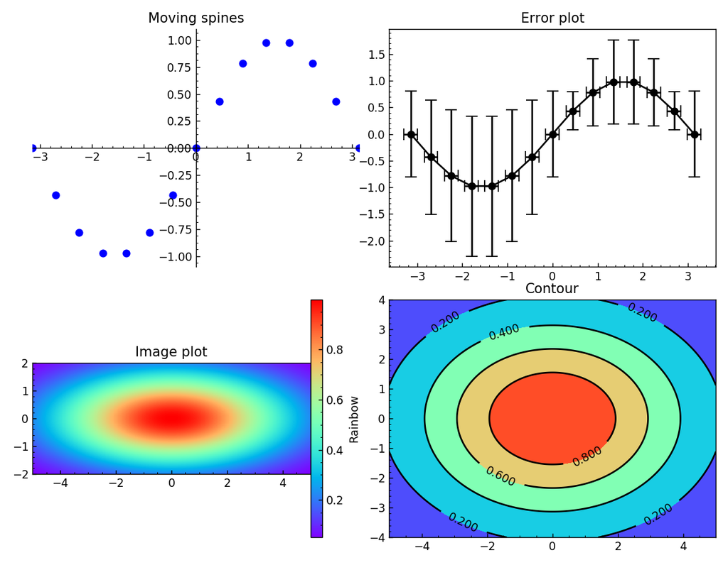

```python
fig, ax = plt.subplots(2, 2, figsize=(9,7))
```

### 3.2.1. Moving spines & Scatter plot

```python
x = np.linspace(-np.pi, np.pi, 15)
y = np.sin(x)
```

```python
p1=ax[0,0].plot(theta, s, 'k')
```

```python
ax[0,0].scatter(x, y, marker='o', c='b', edgecolors= 'b')
```

```python
ax[0,0].set_xlim(-np.pi,np.pi)
ax[0,0].set_ylim(-1.1,1.1)
```

```
(-1.1, 1.1)
```

```python
ax[0,0].set_title('Moving spines')
```

```
Text(0.5,1,'Moving spines')
```

```python
for i in ['top', 'right'] :
    ax[0,0].spines[i].set_color('none')
```

```python
ax[0,0].xaxis.set_ticks_position('bottom')
ax[0,0].yaxis.set_ticks_position('left')
for i in ['left', 'bottom'] :
    ax[0,0].spines[i].set_position(('data',0))
```

```python
p1.pop(0).remove()
```

### 3.2.2. Error plot

```python
yerr= np.sqrt(np.abs(y-0.5))+0.1
```

```python
ax[0,1].errorbar(x, y, xerr=0.15, yerr=yerr,fmt='-o', capthick=1, capsize=5, color = 'k')
```

```
<Container object of 3 artists>
```

```python
ax[0,1].set_title('Error plot')
```

```
Text(0.5,1,'Error plot')
```

### 3.2.3. Plot image

```python
gx= np.linspace(-5,5,500)
gy= np.linspace(-4,4,400)
gauss2d = np.exp(-0.5*(gx/gx.std())**2-0.5*(gy[:,None]/gy.std())**2)
```

```python
gauss2d.shape
```

```
(400, 500)
```

```python
im= ax[1,0].imshow(gauss2d)
```

```python
im.remove()
```

```python
im= ax[1,0].imshow(gauss2d, origin='lower', cmap=plt.cm.rainbow)
```

```python
im.remove()
```

```python
im= ax[1,0].imshow(gauss2d, origin='lower', cmap=plt.cm.rainbow, extent= [-5, 5, -2, 2])
```

```python
cbar= plt.colorbar(im, ax=ax[1,0], pad=0)
```

```python
cbar.set_label('Rainbow')
```

```python
ax[1,0].set_title('Image plot')
```

```
Text(0.5,1,'Image plot')
```

### 3.2.4. Contour

```python
ax[1,1].contourf(gx, gy, gauss2d, 5, cmap=plt.cm.rainbow)
```

```python
c= ax[1,1].contour(gx, gy, gauss2d, 5, colors='k')
```

```python
ax[1,1].clabel(c)
```

```
<a list of 7 text.Text objects>
```

```python
ax[1,1].set_title('Contour')
```

```
Text(0.5,1,'Contour')
```

```python
fig.tight_layout(h_pad=0,w_pad=0)
```

## 3.3. Inset figure

In some cases, we may draw the zoomed a portion of image on the original image like below.

[figure not shown]

In order to insert inset figure on the original image, we first import the mpl_toolkits.

```python
from mpl_toolkits.axes_grid1.inset_locator import zoomed_inset_axes, mark_inset
```

Then we download the [sample image](http://fiss.snu.ac.kr/tutorial/sample/goblin.png).

```python
import os
```

```python
dirn = r'C:\Tutorial\sample'
filen = 'goblin.png'
```

```python
file=os.path.join(dirn,filen)
```

```python
file
```

```
'C:\\Tutorial\\sample\\goblin.png'
```

```python
goblin=plt.imread(file)
```

```python
goblin.shape
```

```
(138, 141, 3)
```

[figure not shown]

```python
fig = plt.figure(figsize=(6,6))
```

```python
ax = plt.subplot(111)
```

```python
im = ax.imshow(goblin, origin='lower')
```

```python
xlim = (57, 78)
ylim = (32, 53)
```

```python
axins = zoomed_inset_axes(ax, 2, loc = 4)
```

```python
axins.imshow(goblin, origin='lower')
```

```python
axins.set_xlim(xlim)
axins.set_ylim(ylim)
```

```
(32, 53)
```

```python
axins.tick_params(left='off', right='off', top='off', bottom='off', labelleft='off', labelbottom='off')
```

```python
mark_inset(ax, axins, loc1=1, loc2=3)
```

```
(<mpl_toolkits.axes_grid1.inset_locator.BboxPatch at 0xf5bed28f28>,
 <mpl_toolkits.axes_grid1.inset_locator.BboxConnector at 0xf5bb6da898>,
 <mpl_toolkits.axes_grid1.inset_locator.BboxConnector at 0xf5be6ad828>)
```

### $+ \alpha)$ Annotation

```python
ax.annotate('Cute-eye', xy=(53, 70), xytext=(9,125), arrowprops=dict(fc='r', shrink=0.03), fontweight='bold')
```

```
Text(9,125,'Cute-eye')
```

### $\star$ Well-fitted colorbar

```python
from mpl_toolkits.axes_grid1 import make_axes_locatable
```

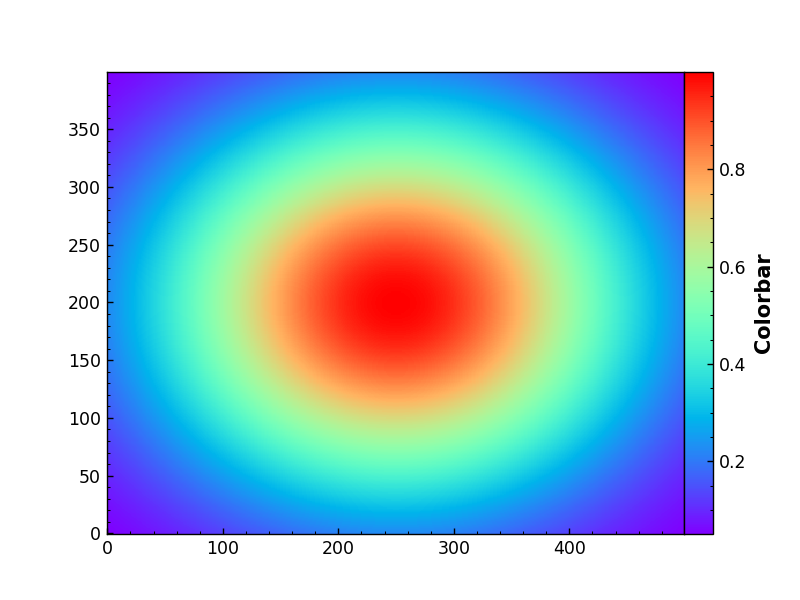

```python
ax = plt.subplot(111)
```

```python
im = ax.imshow(gauss2d, origin='lower', cmap= plt.cm.rainbow)
```

```python
divider = make_axes_locatable(ax)
```

```python
cax = divider.append_axes('right', size='5%', pad=0)
```

```python
cbar = plt.colorbar(im, cax=cax)
```

```python
cbar.set_label('Colorbar', fontweight='bold', fontsize=12)
```

# 4. Scientific Tools (SciPy Package)

In this section, we learn the useful function to analyze a data.

## 4.1. FFT

"A fast Fourier transform (FFT) is an algorithm that samples a signal over a period of time (or space) and divides it into its frequency components." ([Wikipedia](https://en.wikipedia.org/wiki/Fast_Fourier_transform))

Basic fft functions are contained in scipy.fftpack module.

```python
from scipy import fftpack
```

```python
fftpack.fft
```

```
<function scipy.fftpack.basic.fft>
```

We download the [example file](http://paos.colorado.edu/research/wavelets/wave_idl/sst_nino3.dat), and apply fft to the data

```python
example = r'C:/Tutorial/sample/sst_nino3.dat'
```

To read this we use the numpy.loadtxt() function.

```python
data = np.loadtxt(example)
```

```python
len(data)
```

```
504
```

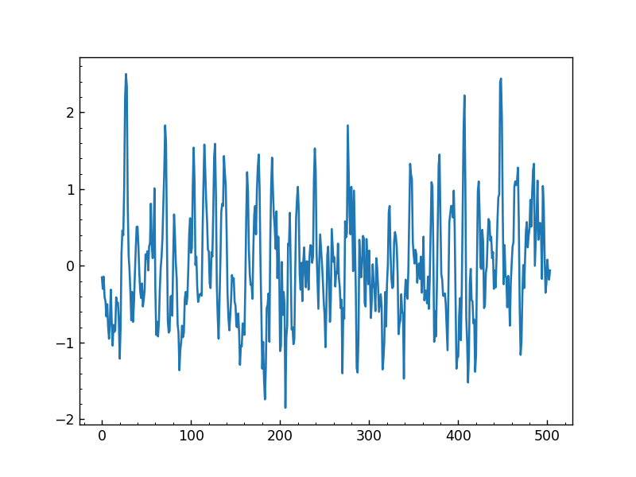

```python
plt.plot(data)
```

```python
fdata = fftpack.fft(data)
```

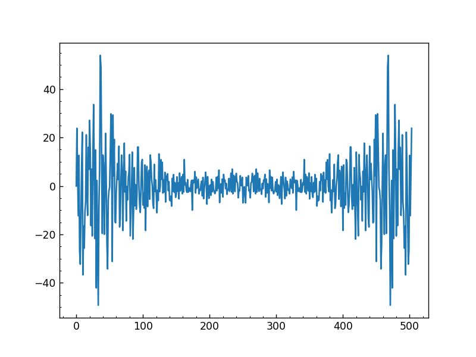

```python
plt.plot(fdata)
```

```python
repro = fftpack.ifft(fdata)
```

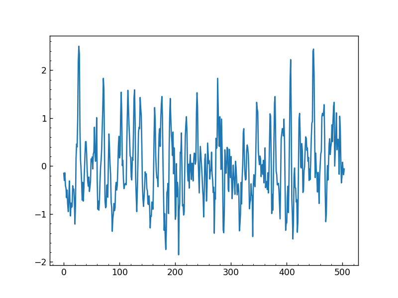

```python
plt.plot(repro)
```

```python
fdata[50:452]=0
```

```python
repro2 = fftpack.ifft(fdata)
```

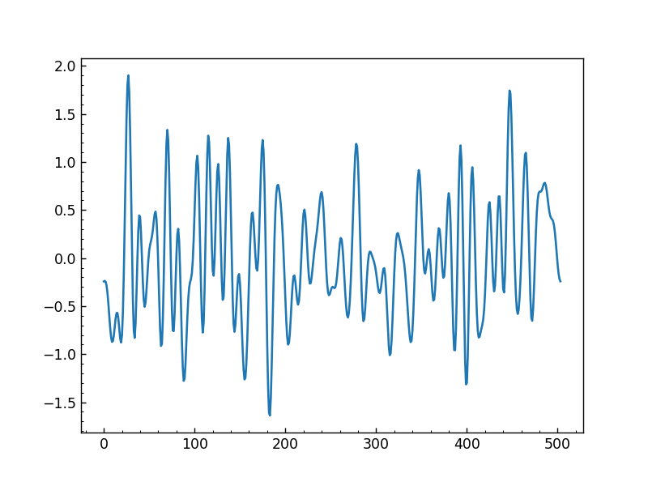

```python
plt.plot(repro2)
```

## 4.2. Convolution

We apply the gaussian convolution kernal to goblin image.

In this section, we use the fftconvolve function since it is faster than convolve function.

```python
from scipy.signal import fftconvolve
```

```python
kern = np.array([[1,2,1],[2,4,2],[1,2,1]])/16
```

```python
convimg = [fftconvolve(goblin[:,:,i], kern, mode='same') for i in range(3)]
```

```python
convimg = np.array(convimg)
```

```python
convimg.shape
```

```
(3, 138, 141)
```

```python
convimg=convimg.transpose((1,2,0))
```

```python
convimg.shape
```

```
(138, 141, 3)
```

[figure not shown]

```python
fig, ax = plt.subplots(1,2,figsize=(8,5))
```

```python
ax[0].imshow(goblin)
```

```python
ax[1].imshow(convimg)
```

## 4.3. Fitting

### 4.3.1. Polynomial fittng

Let's fit polynomial to data. Here, we use the **nummpy polynomial()** fitting function.

```python
x = np.arange(len(data))
y = data.copy()
```

```python
pfcoeff = np.polyfit(x, y, 1)
```

The polyfit function gives the fitting coefficients for given data.

```python
pfcoeff
```

```
array([ 0.00052717, -0.1326027 ])
```

To create the polynomial fitting curve, we use the **numpy.polyval()** function.

```python
pfval = np.polyval(pfcoeff, x)
```

Then, let's plot the original data and fitting curve

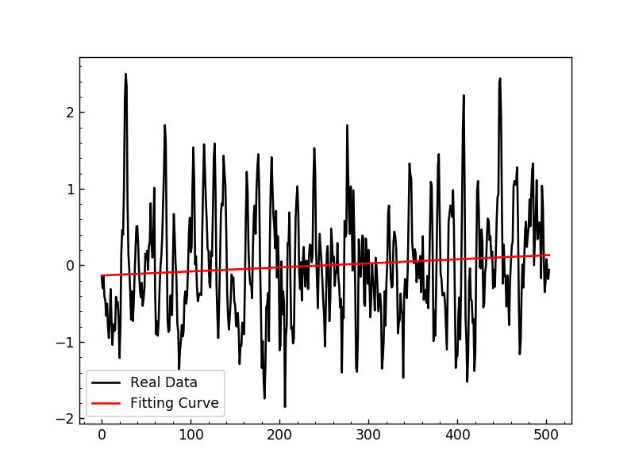

```python
plt.plot(x, y, 'k', label='Real Data')
```

```python
plt.plot(x, pfval, 'r', label='Fitting Curve')
```

```python
plt.legend()
```

### 4.3.2. Model fitting

In, this sub-section, we fit sinosidal function to the data.

At first, we make a sinosidal function.

```python
def func(theta, p0, p1, p2, p3):
    return p0*np.sin(p1*theta+p2)+p3
```

Then import the **curve_fit()** function.

```python
from scipy.optimize import curve_fit
```

Now we guass an initial value for fitting function

```python
init = [2, 0.5, 0.1, -1]
```

```python
xs = x[100:150]
ys = y[100:150]
```

Let's fit the given function to data.

```python
coeff, cov = curve_fit(func, xs, ys, p0=init)
```

```python
print(coeff)
```

```
[ 0.77459613  0.54645094 -4.62010486  0.22718251]
```

```python
yfit = func(xs, *coeff)
```

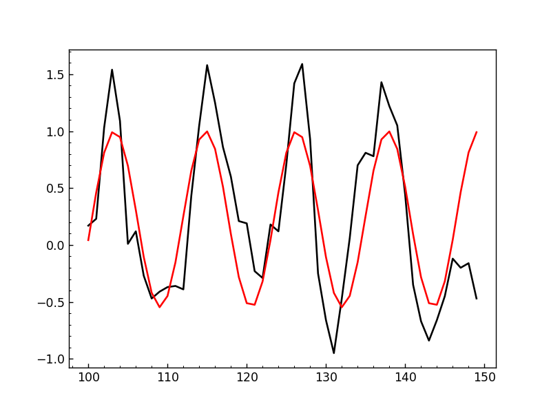

```python
plt.plot(xs, ys, 'k', label='Real Data')
```

```python
plt.plot(xs, yfit, 'r', label='Fitting Curve')
```

## 4.4. Interpolation

In general, many python user use the scipy interpolation module for interpolate data. However, this interpolation is somewhat slower than IDL's one, since the for loop in python is very slower than any other programming language. If there are many data which have to be applyed the interpolation, that take some time. In order to solve this slow speeding interpolation, there is [interpolation package](https://github.com/econforge/interpolation.py) which is wriiten by using the [Numba package](https://numba.pydata.org/).

Numba package make python code be [Just-In-Time](https://en.wikipedia.org/wiki/Just-in-time_compilation) copiled to native machine instructions, similar in performance to C, C++ and Fortran.

At first we download the interpolation package. Excute the below command line on your terimal or cmd prompt:

```
conda install -c conda-forge interpolation
```

### 4.4.1. Scipy interpolation (1D case)

Before we use this interpolation package, we learn the general interpolation function which is included in scipy package.

```python
from scipy.interpolate import interp1d
```

```python
interpf = interp1d(xs, ys, kind='cubic')
```

```python
xin = np.linspace(xs.min(), xs.max(), 3*len(xs))
```

```python
yin = interpf(xin)
```

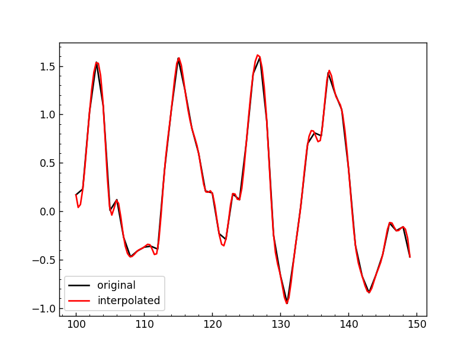

```python
plt.plot(xs, ys, 'k', label= 'original')
```

```python
plt.plot(xin, yin, 'r', label ='interpolated')
```

```python
plt.legend()
```

### 4.4.2. Fast Interpolation ($\geq$ 2D case)

This package tool will be explained in YSSS tutorial.

```python
from interpolation.splines import LinearSpline
```

First, define the grid boundaries

```python
ny, nx, nc =goblin.shape
```

```python
lower = np.array([0,0,0])
upper = np.array([ny-1,nx-1,nc-1])
order = np.array(goblin.shape)
```

```python
interp = LinearSpline(lower, upper, order, goblin)
```

```python
ya = np.linspace(0,ny-1,ny*2)
xa = np.linspace(0,nx-1,nx*2)
ca = np.arange(0,nc)
zero = np.zeros((2*ny,2*nx,nc))
```

```python
yy = ya[:,None,None]+zero
xx = xa[:,None]+zero
cc = ca+zero
```

```python
size = yy.size
```

```python
size
```

```
233496
```

```python
input_a = np.array([yy.reshape(size), xx.reshape(size), cc.reshape(size)])
```

```python
out = interp(input_a.T)
res = out.reshape((2*ny,2*nx,nc))
```

[figure not shown]

```python
plt.imshow(res)
```

## 4.5. Optimization (Minimization)

In this section we lean how to find maximum or minimum of an objective function numerically.

We use one of minimization method, [Amoeba method](https://en.wikipedia.org/wiki/Nelder%E2%80%93Mead_method)(= Nelder-Mead method = downhill simplex method)

```python
from scipy.optimize import minimize
```

Let's derive the minimization solution of below function.

$f(x,y) = 100(y-x^2)^2+(1-x)^2$

(1) Create the above function.

```python
def minifunc(X) :
    x, y = X
    return 100*(y-x**2)**2+(1-x)**2
```

(2) Choose initial value.

```python
X0 = [-0.5, -0.5]
```

```python
res = minimize(minifunc, X0, method='Nelder-Mead')
```

```python
res
```

```
 final_simplex: (array([[ 1.00002709,  1.000054  ],
       [ 1.00000482,  1.00000328],
       [ 1.0000603 ,  1.00011627]]), array([  7.36938378e-10,   4.07353785e-09,   5.51563470e-09]))
           fun: 7.3693837805430572e-10
       message: 'Optimization terminated successfully.'
          nfev: 139
           nit: 75
        status: 0
       success: True
             x: array([ 1.00002709,  1.000054  ])
```

```python
res['x']
```

```
array([ 1.00002709,  1.000054  ])
```

**Exercies 6) Find the minimized value for below function by using Nelder-Mead method starting from (x,y)=(0,0).**

$f(x,y) = 2x^2+y^2-2xy+\left|x-3\right|+ \left|y-2\right|$

## 4.6. Noise suppresion (Savitzky-Golay Filter)

In general, digital data have noise. In some case noise can highly affect the real signal. To supprese this, many researcher develope smooting methods. Among those smooting methods, [Savitzky-Golay Filter](https://en.wikipedia.org/wiki/Savitzky%E2%80%93Golay_filter) is most famous way to reduce noise. Savitzky-Golay filter increases the signal-to-noise ratio without greatly distorting the signal. This is achieved, in a process known as convolution, by fitting successive sub-sets of adjacent data points with a low-degree polynomial by the method of linear least squares. ([Wikipedia](https://en.wikipedia.org/wiki/Savitzky%E2%80%93Golay_filter))

[figure not shown]

We use also sst_nino data in this section.

```python
from scipy.signal import savgol_filter
```

```python
sgfy = savgol_filter(y, 9, 3)
```

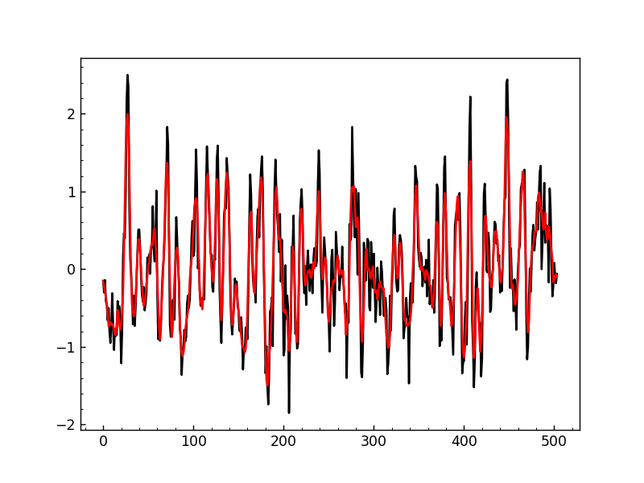

```python
plt.plot(x,y,'k')
```

```python
plt.plot(x, sgfy, 'r')
```

**Exercise 7) Apply the Savitzky-golay filter to sst_nino data with window length = 9 and polynomial order = 5. After that, overplot the result on the above figure. Finally, Fourier trnasform the result. Is there any diffrence with the previous result?**

## 4.7. Read IDL sav data

Download the sample [sav file](http://fiss.snu.ac.kr/tutorial/sample/sample.sav).

```python
from scipy.io import readsav
```

```python
filen = r'C:/Tutorial/sample/sample.sav'
```

```python
sdata = readsav(filen)
```

```python
sdata.keys()
```

```
dict_keys(['t', 'timeseries'])
```

```python
t = sdata['t']
```

```python
t.shape
```

```
(200,)
```

```python
series = sdata['timeseries']
```

```python
series.shape
```

```
(200, 3, 6)
```

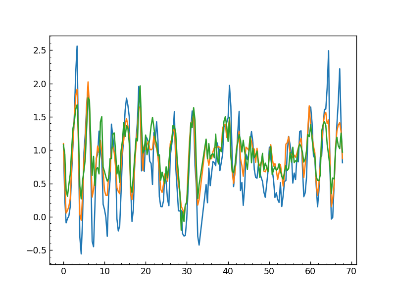

```python
plt.plot(t, series[:,:,1])
```

# 5. Fits file handling (AstroPy Package)

In order to read the fits file we need to AstroPy package.

In this section we only focous on the way to read fits file. First, we dowload example the [fits file](https://www.spacetelescope.org/static/projects/fits_liberator/datasets/eagle/502nmos.zip).

```python
filen = r'C:/Tutorial/sample/502nmos.fits'
```

```python
from astropy.io import fits
```

```python
data = fits.getdata(filen)
header = fits.getheader(filen)
```

```python
header['naxis1']
```

```
1600
```

```python
data.shape
```

```
(1600, 1600)
```

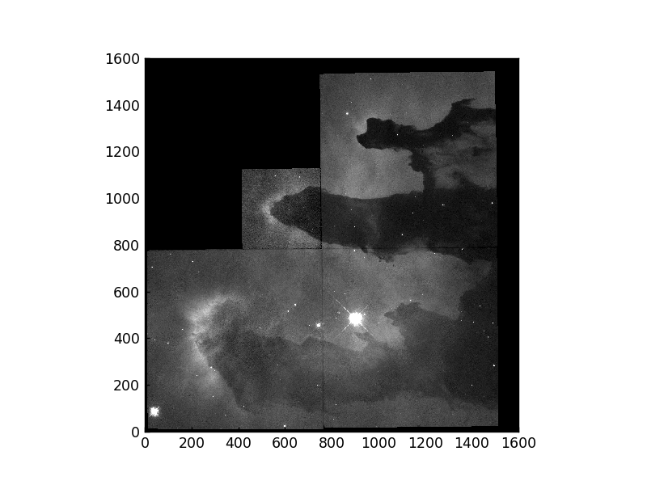

```python
plt.imshow(data,origin='lower',cmap=plt.cm.gray)
```

```python
plt.clim(0,30)
```

```python
plt.draw()
```

## 5.2. Astronomical units and constants

In AstroPy package, there are many useful physical constants and units.

```python
import astropy.constants as c
```

```python
kb=c.k_B   # Boltzmann constant
```

```python
import astropy.units as u
```

```python
T=1e3*u.K
```

```python
E=kb*T
```

```python
E.cgs
```

$1.3806485 \times 10^{-13} \; \mathrm{erg}$

# 6. Solar software for python (SunPy)

[Sunpy](http://sunpy.org/) is the python version Solar Software.

It is free and open source package written in Python.

However, this package is not developed package, but developing one. So, it may occur any errors at this time. To download this package run the below terminal command

```
conda install -c conda-forge sunpy
```

In this tutorial we skip this part, If you interested in this package and need to guide documentation, please check this [SunPy website](http://sunpy.org/) and its [documentation](http://docs.sunpy.org/en/stable/guide/index.html)